# CSCI E-63C Week 8 Assignment

# Preface

In this assignment we will exercise some of the measures for evaluating “goodness of clustering” presented in the lecture this week on the clusters obtained for the World Health Statistics (WHS) dataset from week 6. Please feel free to adapt/reuse code presented in lecture slides as necessary or implementations already available in R. All problems in this assignment are expected to be performed on *scaled* WHS data – if somewhere it does not mention it explicitly, please assume that it is scaled data that should be used.

Lastly, as a dose of reality check: WHS is a dataset capturing variability of population health measures across more or less the entire diversity of societies in the world – please be prepared to face the fact that resulting clustering structures are far from textbook perfect, may not be very clearly defined, etc.

## Note on quakes data (and *3 extra points per problem*)

As you will notice, WHS dataset does not have the most striking cluster structure to it - at least as far as formal measurements of cluster strength that we are working with in this assignment are concerned (or the notion that there is well defined “optimal” number of clusters when split of observations into larger or smaller groups results in “worse” metrics). Not an uncommon situation for the data we have to work with at all.

As an opportunity to see the output of the code that you are using/developing for this assignment when applied to a dataset with more distinct substructure (and earn extra points by doing that) for each of the five problems there are in this assignment (four required, one for extra points) once you generated required plots for WHS dataset, adding the same kinds of plots but for a standard R dataset “quakes” will be earning *3 extra points* for each problem. So that if everything works perfectly this could add 15 extra points to the total to this assignment (5 problems including an extra point problem times 3 extra points each) so that along with the extra 5 points problem below, this assignment has potential of adding up to 20 extra points to your homework total.

Dataset “quakes” is routinely available in R upon log in - to “see” it, the following should just work without any further steps for a standard R installation:

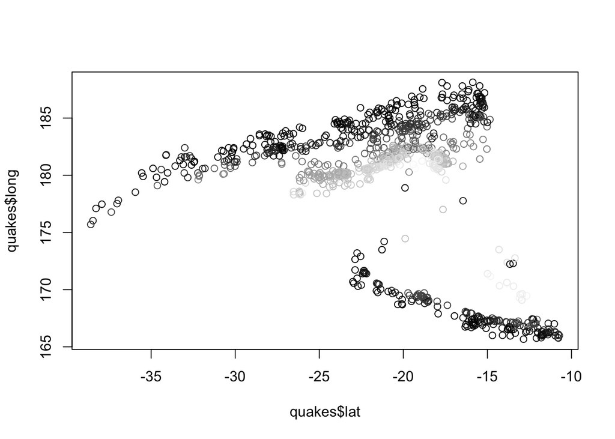

```r
clr <- gray((quakes$depth-min(quakes$depth))/range(quakes$depth)%*%c(-1,1))
plot(quakes$lat,quakes$long,col=clr)
```

or, similarly, if you are a ggplot fan (in which case you will know to load ggplot2 library first):

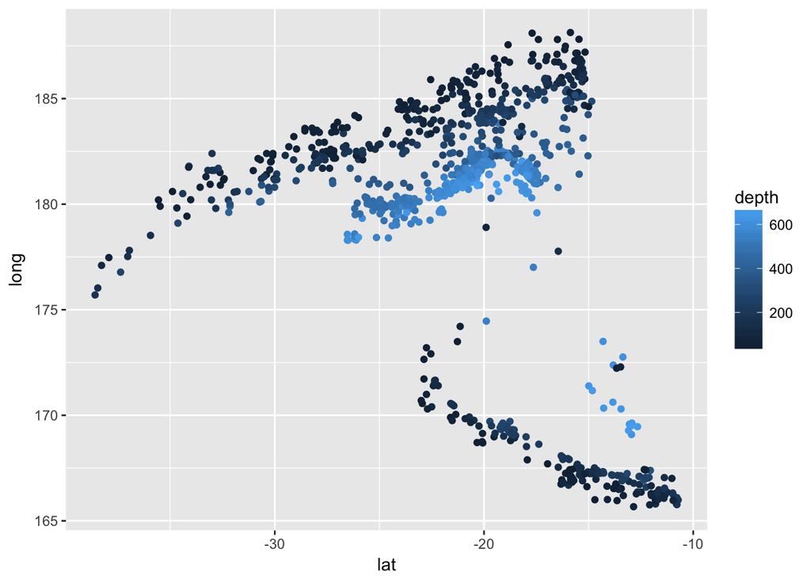

```r
ggplot(quakes,aes(x=lat,y=long,colour=depth))+geom_point()
```

If you write your code with reusability in mind, applying it to “quakes” should be just a straightforward drop in replacement of WHS data frame with that of “quakes”. You will see that the subclasses of observations are so well defined in “quakes” that is almost boring in its own way. Nothing is perfect in this world, but you should see more interesting behavior of CH index in this case, for example.

# Problem 1: within/between cluster variation and CH-index (15 points)

Present plots of (total) within and between cluster variance provided by K-means clustering on scaled WHS data for 2 through 20 clusters. Choose large enough value of `nstart` for better stability of the results across multiple trials and evaluate stability of those results across several runs. Discuss the results and whether the shape of the curves suggest specific number of clusters in the data.

```r
#Read tab separated whs data
whs <- read.table("whs2016_AnnexB-data-wo-NAs.txt", sep = "\t", quote=NULL)

head(whs)
```

```
##                   TOTPOP LIFEXPB.M LIFEXPB.F LIFEXPB.B  HLIFEXP  MATMORT
## Afghanistan        32527   59.3000  61.90000  60.50000 52.20000 396.0000
## Albania             2897   75.1000  80.70000  77.80000 68.80000  29.0000
## Algeria            39667   73.8000  77.50000  75.60000 66.00000 140.0000
## Andorra               70   68.8765  73.73497  71.28798 62.80437 170.2376
## Angola             25022   50.9000  54.00000  52.40000 45.80000 477.0000
## AntiguaandBarbuda     92   74.1000  78.60000  76.40000 67.50000 170.2376
##                   MEDBIRTHS MORTLT5YO NEONMORT   NEWHIV TBINC   MALARIA
## Afghanistan        45.00000      91.1     35.5 0.100000 189.0  15.70000
## Albania            99.00000      14.0      6.2 1.563303  19.0  96.96442
## Algeria            97.00000      25.5     15.5 0.100000  78.0   0.10000
## Andorra            84.27624       2.8      1.4 1.563303   9.2  96.96442
## Angola             47.00000     156.9     48.7 2.100000 370.0 145.70000
## AntiguaandBarbuda 100.00000       8.1      4.9 1.563303   7.6  96.96442
##                   HEPBVACC INTINTDS PRMORT3070   SUICIDE ALCONS MORTRAFF
## Afghanistan             75 13406517   30.50000  4.000000    1.0     15.5
## Albania                 98       42   18.80000  6.500000    6.6     15.1
## Algeria                 95  9817345   22.10000  1.800000    0.6     23.8
## Andorra                 96        0   19.01628  9.387719    9.1      7.6
## Angola                  80 17668111   24.20000 10.600000    7.6     26.9
## AntiguaandBarbuda       99     1395   19.01628  9.387719    3.2      6.7
##                   MODFAMPLAN ADOBIRTHS MORTAIR MORTWASH MORTPOIS   SMOK.M
## Afghanistan         54.70656  51.90000 112.600  34.6000 7.400000 34.09766
## Albania             12.90000  19.70000 171.400   0.2000 1.400000 51.20000
## Algeria             77.20000  12.40000  31.500   2.4000 1.100000 34.09766
## Andorra             54.70656   4.40000  63.925  13.2814 2.261628 37.20000
## Angola              54.70656 190.90000 104.400 111.2000 5.500000 34.09766
## AntiguaandBarbuda   54.70656  55.54032  63.925  13.2814 2.261628 34.09766
##                     SMOK.F   DRDENS AVEI13HRCCS STUNT5YO  WAST5YO    OW5YO
## Afghanistan       11.64922  7.70000    45.00000 40.90000 9.500000  5.40000
## Albania            7.60000 49.90000    73.18229 23.10000 9.400000 23.40000
## Algeria           11.64922 31.50000    73.00000 11.70000 4.100000 12.40000
## Andorra           27.80000 87.60000    29.00000 23.15188 6.132824  7.05748
## Angola            11.64922 18.30000    18.00000 29.20000 8.200000  7.05748
## AntiguaandBarbuda 11.64922 57.14431    88.00000 23.15188 6.132824  7.05748
##                   BETTERH2O BETTERSAN CLEANFUEL AVEPM2.5   DEATHND
## Afghanistan              55  32.00000        17     64.1 0.8000000
## Albania                  95  93.00000        67     17.1 0.0000000
## Algeria                  84  88.00000        95     26.0 0.1000000
## Andorra                 100 100.00000        95     10.5 0.2245902
## Angola                   49  52.00000        48     42.8 0.1000000
## AntiguaandBarbuda        98  73.07143        95     15.0 0.0000000
##                   HOMICIDE DEATHCONF
## Afghanistan            7.3 40.900000
## Albania                5.0  0.100000
## Algeria                4.4  1.000000
## Andorra                0.8  3.509302
## Angola                10.7  0.000000
## AntiguaandBarbuda      4.4  3.509302
```

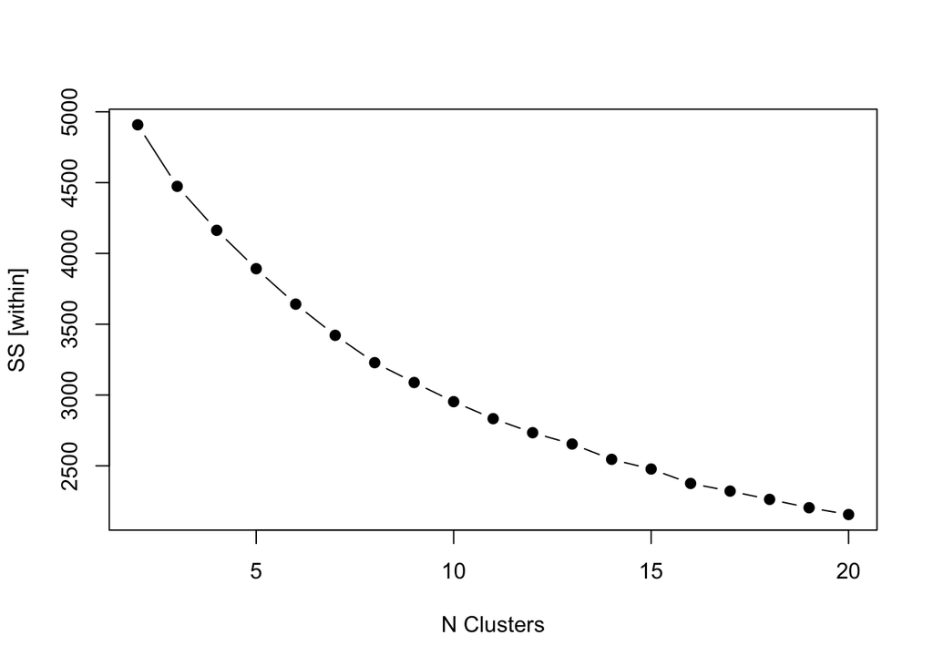

```r
#Explictely scale data
s.whs <- scale(whs)


xClust <- function(dat, n=20, ns=25){
  set.seed(1234)
  ch <- numeric(n-1)
  within <- numeric(n-1)
  between <- numeric(n-1)
  for (c in 2:n) {
    km <- kmeans(dat, c, nstart = ns)
    within[c-1] <- km$tot.withinss
    between[c-1] <- km$betweenss

    #CH Index
    ch[c-1] <- (km$betweenss/(c-1))/(km$tot.withinss/(length(km$cluster)-c))
  }
  list(w=within, b=between, ch=ch)
}


xc <- xClust(s.whs)

plot (2:20,xc$w, ylab="SS [within]", type="b", pch=19, xlab = "N Clusters")
```

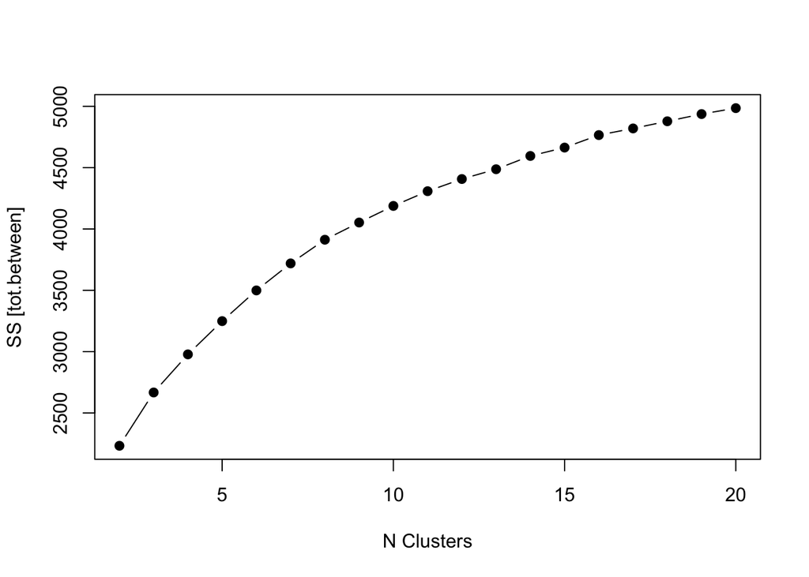

```r
plot (2:20,xc$b, ylab="SS [tot.between]", type="b", pch=19, xlab = "N Clusters")
```

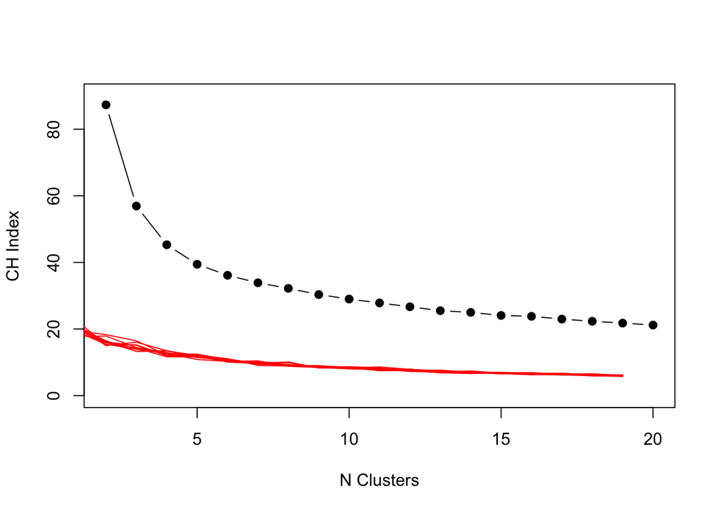

```r
plot (2:20,xc$ch, ylab="CH Index", type="b", pch=19, xlab = "N Clusters",ylim=c(0,90))


# From the plots above, we can see that no obvious "elbow" emerges if we just look at the within and total sum-of squares. Increasing the number of clusters increases the total between sum of squares and minimizes the withs sum of squares. This suggest a lack of stable clusters. CH-index also shows no discernable good candidate of cluster numbers.
for ( i in 1:10 ) {
  chrnd = numeric()
  for ( k in 2:20 ) {
    krnd = kmeans(apply(s.whs,2,function(x)runif(length(x),min(x),max(x))),k)
    chrnd[k-1] = (krnd$betweenss/(k-1))/ (krnd$tot.withinss/(length(krnd$cluster)-k))
  }
  points(chrnd,type="l",col="red")
}
```

```r
#Plotting alongside samples from a uniform distribution, we can see that the CH-Index is at its maximum at 2 clusters,  after 3 clusters, the trend of the uniform and the CH-Index is similar. However our data is not random.

# Quakes data

s.quakes <- scale(quakes)

head(s.quakes)
```

```
##              lat      long      depth        mag   stations
## [1,]  0.04429494 0.3555451  1.1628201  0.4459088  0.3462039
## [2,]  0.00452395 0.2583377  1.5711055 -1.0437642 -0.8409897
## [3,] -1.06531573 0.7641457 -1.2497756  1.9355817  0.4375265
## [4,]  0.53148959 0.3621355  1.4597549 -1.2920430 -0.6583446
## [5,]  0.04429494 0.4115630  1.5664659 -1.5403218 -1.0236349
## [6,]  0.19144761 0.7987450 -0.5399157 -1.5403218 -0.9779736
```

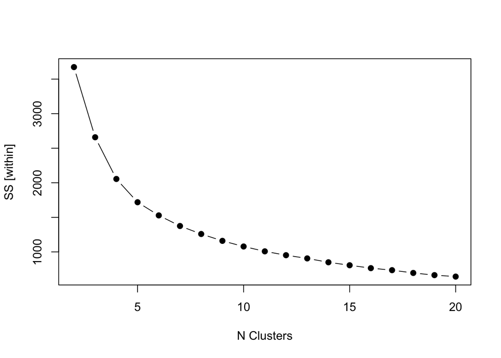

```r
qc <- xClust(s.quakes)

plot (2:20,qc$w, ylab="SS [within]", type="b", pch=19, xlab = "N Clusters")
```

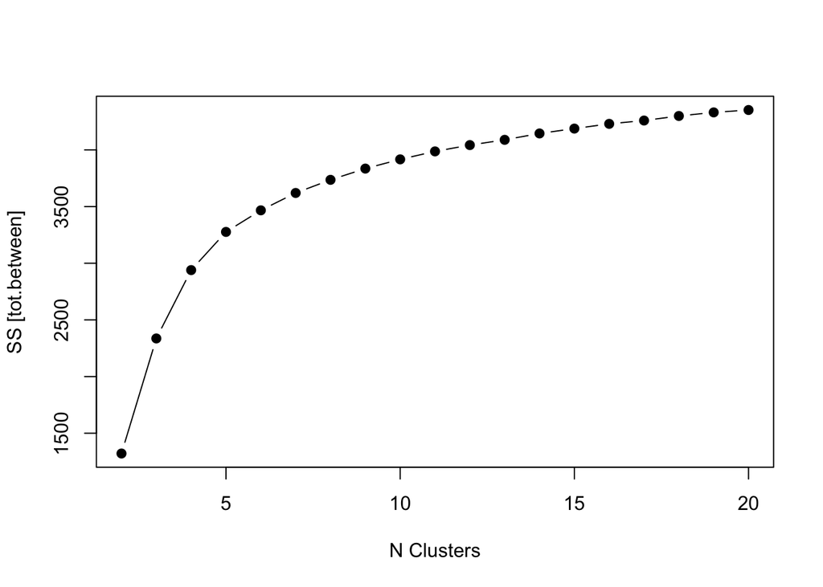

```r
plot (2:20,qc$b, ylab="SS [tot.between]", type="b", pch=19, xlab = "N Clusters")
```

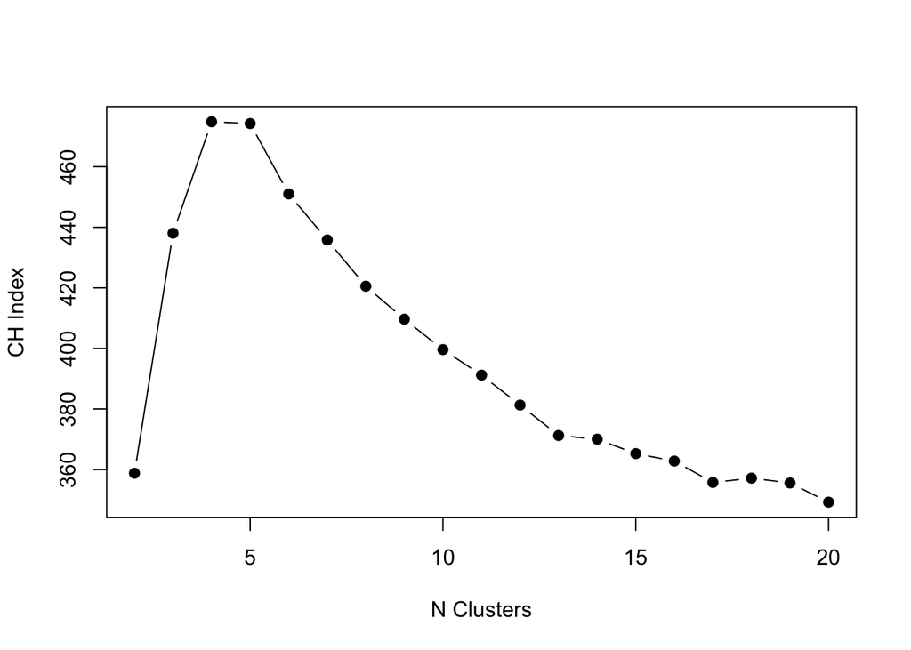

```r
plot (2:20,qc$ch, ylab="CH Index", type="b", pch=19, xlab = "N Clusters")
```

```r
#With the quakes dataset, we have much clearer clustering than what was observed in the WHS dataset
# Both the total between  and within sum of squares seems to indicate that 4 clusters is the optimal number of clusters. This belief is reinforced with the CH- Index data
```